# FORESIGHTV. Exploratory data analysis. Variables socioeconómicas

Jhonander Nunes, Fabio Natalini

# 1 Introducción

En este análisis estudiamos las variables macroeconómicas y sociales que se incluyeron en las independientes de los modelos del primer desarrollo del Foresightv. En este nuevo desarrollo, además, se añade el coste de los GRP, cuya variabilidad en el tiempo influye en las negociaciones para la emisión de anuncios en TV, y se supone que la inflación en el mercado de los anuncios televisados sigue unas dinámicas que no se pueden describir adecuadamente con el IPC.  
Vamos a analizar la relación de estas variables con las métricas de la televisión, GRP y audiencia (minutos de consumo), para evaluar su rol en el ajuste de los modelos y definir la lógica de su uso.  
El análisis se realiza tomando los GRP y los minutos de consumo de `TTV`, total TV.

# 2 Datos input

Recopilamos los datos socioeconómicos: número de afiliados a la seguridad social, IPC, ICC (índice de confianza del consumidor).  
Añadimos el nuevo dato del coste por GRP, referido a *ind. 4+*, el target con el que trabajamos en este nuevo desarrollo del Foresightv.  
Desarrollamos el análisis con dos aproximaciones: una primera aproximación visual comparando variables, y una segunda aproximación estadística mediante modelos de regresión exploratorios.  
Sabemos que existe un efecto de la pandemia de COVID-19, por lo que vamos a importar también los datos de contagios. Asimismo, calculamos la estacionalidad anual de las dos métricas de la televisión. Necesitaremos ambas variables para las regresiones.

```r
library(dplyr)
library(readxl)
library(tidyr)
library(forecast)
library(corrplot)

root.path <- "J:/PMED_Practices/Data_Sciences/Advanced Analytics/Ninah/PROYECTOS AA/Proyecto Colaboracion UCM/01 Proyecto TV alpha"
input.path <- "01 datos/04 variables socioeconomicas"
input.data <- "macro_actualizadoDic22.xlsx"
input.data.costes <- "costes_grp.xlsx"
input.data.covid <- "casos_hosp_uci_def_sexo_edad_provres.csv"
input.path.processed.data <- "01.1 datos procesados"
input.grp.data <- "grp_2018-01-01_2022-12-31.RDS"
input.audi.data <- "audiencia_2018-01-01_2023-01-31.RDS"
fecha.ini <- as.Date("2018-01-01")
fecha.fin <- as.Date("2022-12-31")
confinamiento.ini <- as.Date("2020-03-14")
confinamiento.fin <- as.Date("2020-06-21")

# afiliados Seguridad Social, índice de confianza del consumidor, ipc
datos <- read_excel(
  file.path(root.path, input.path, input.data),
  sheet = "real",
  range = "A1:D133",
  col_names = TRUE
) |> data.frame()
datos$fecha <- as.Date(datos$fecha)
datos <- datos %>% filter(between(fecha, fecha.ini, fecha.fin))
names(datos)[which(names(datos)=="fecha")] <- "dia"

# costes mensuales GRP
costes <- read_excel(
  file.path(root.path, input.path, input.data.costes),
  sheet = "Coste Ind4+",
  col_names = TRUE
) |> data.frame()
costes$mes <- as.Date(costes$mes)
costes <- costes %>% filter(between(mes, fecha.ini, fecha.fin))
names(costes)[which(names(costes)=="mes")] <- "dia"

# datos televisión
grp.data <- readRDS(file.path(root.path,input.path.processed.data,input.grp.data))
audi.data <- readRDS(file.path(root.path,input.path.processed.data,input.audi.data))

grp.data <- grp.data %>% filter(between(Fecha, fecha.ini, fecha.fin)) %>%
  filter(Cadena=="TTV") %>% group_by(Fecha) %>% summarise(GRP = sum(GRP)) |> data.frame()

audi.data <- audi.data %>% filter(between(Fechas, fecha.ini, fecha.fin)) %>%
  filter(Cadenas=="TTV") %>% group_by(Fechas) %>% summarise(minutos = sum(`MAud [minutos]`)) |> data.frame()

names(grp.data)[which(names(grp.data)=="Fecha")] <- "dia"
names(audi.data)[which(names(audi.data)=="Fechas")] <- "dia"

# estacionalidad anual de los datos de televisión
grp.data.ts <- forecast::msts(grp.data[,"GRP"], seasonal.periods=c(7, 7*52.18), start=c(1,1))
grp.data.mstl <- forecast::mstl(grp.data.ts, robust=TRUE)
grp.data[,"GRP.yearly"] <- grp.data.mstl[,"Seasonal365.26"]

audi.data.ts <- forecast::msts(audi.data[,"minutos"], seasonal.periods=c(7, 7*52.18), start=c(1,1))
audi.data.mstl <- forecast::mstl(audi.data.ts, robust=TRUE)
audi.data[,"audi.yearly"] <- audi.data.mstl[,"Seasonal365.26"]

# contagios covid
covid <- data.table::fread(file.path(root.path,input.path,input.data.covid),
                           sep=",", header=TRUE, colClasses=c(rep("character",3), "Date", rep("numeric",4)))

covid <- covid %>% filter(between(fecha, fecha.ini, fecha.fin))

covid <- aggregate(covid$num_casos, by=list(covid$fecha), FUN=sum)

names(covid) <- c("dia","casos.covid")

# conjunto
conjunto <- full_join(grp.data, audi.data, by="dia") %>%
  full_join(datos, by="dia") %>%
  full_join(costes, by="dia") %>%
  full_join(covid, by="dia")

conjunto <- conjunto %>%
  tidyr::fill(ipc, .direction="down") %>%
  tidyr::fill(afiliados, .direction="down") %>%
  tidyr::fill(confianza, .direction="down") %>%
  tidyr::fill(coste, .direction="down")

conjunto$casos.covid[is.na(conjunto$casos.covid)] <- 0

conjunto[,"covid.1"] <- ifelse(conjunto$dia>=confinamiento.ini & conjunto$dia<=confinamiento.fin,
                               conjunto$casos.covid, 0)
```

# 3 Relaciones entre televisión y variables macroeconómicas y sociales

## 3.1 Aproximación visual

Vamos a visualizar las series de GRP y minutos de consumo junto con las variables socioeconómicas y el coste por GRP. Además calculamos el coeficiente de correlación entre las variables socioeconómicas y el coste por GRP.

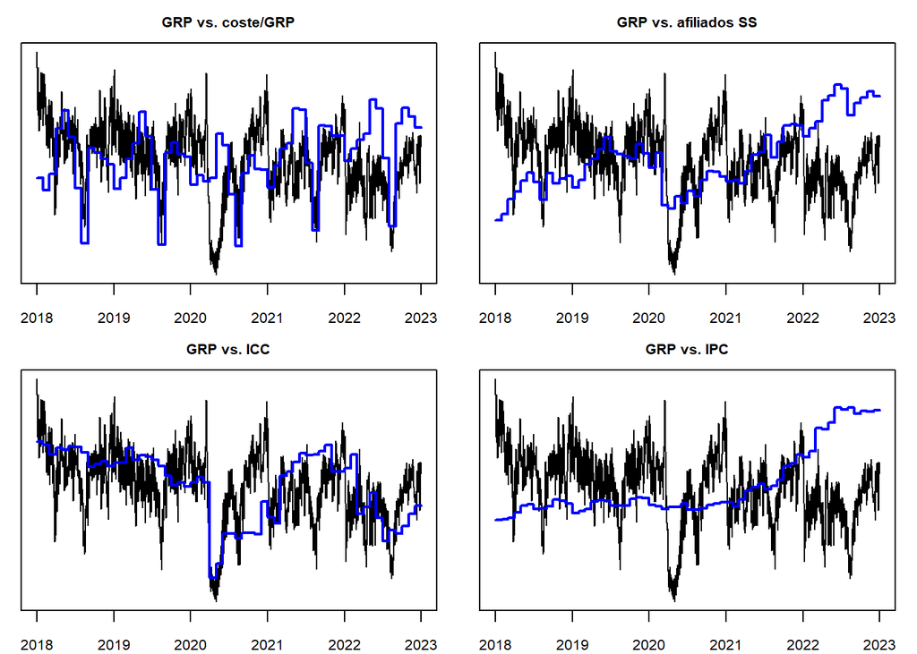

```r
# visualización
conjunto.scale <- cbind(conjunto["dia"], scale(conjunto[,-which(names(conjunto)=="dia")]))

y <- function(tabla, titulo, kpi1, kpi2){
  plot(x=tabla[,"dia"], y=tabla[,kpi1],yaxt="n",type='l',col='black',ylab="",xlab="",main=titulo)
  lines(x=conjunto.scale[,"dia"], y=conjunto.scale[,kpi2],col='blue',lwd=2)
}
par(mar=c(2,1,2,1),cex.main=0.8,cex.axis=0.8,mfrow=c(2,2))
y(tabla=conjunto.scale, titulo="GRP vs. coste/GRP", kpi1="GRP", kpi2="coste")
y(tabla=conjunto.scale, titulo="GRP vs. afiliados SS", kpi1="GRP", kpi2="afiliados")
y(tabla=conjunto.scale, titulo="GRP vs. ICC", kpi1="GRP", kpi2="confianza")
y(tabla=conjunto.scale, titulo="GRP vs. IPC", kpi1="GRP", kpi2="ipc")
```

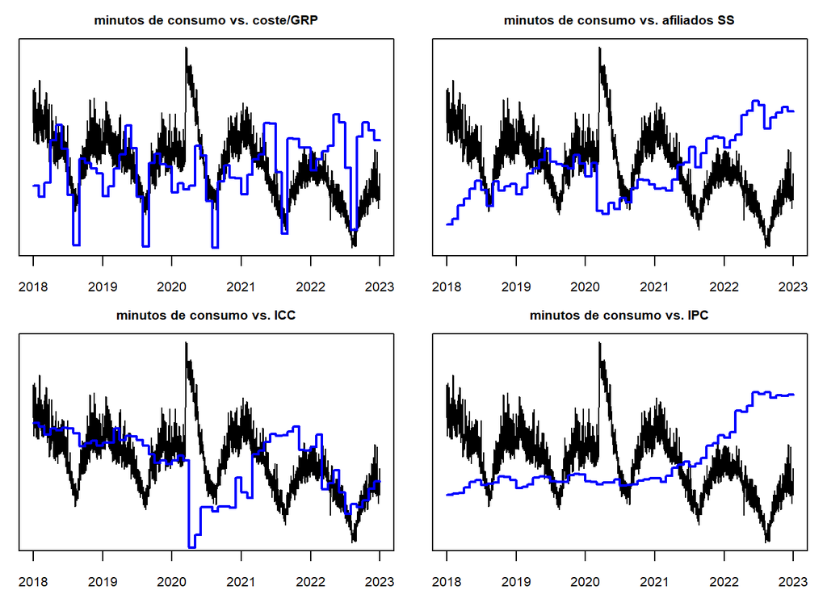

```r
y(tabla=conjunto.scale, titulo="minutos de consumo vs. coste/GRP", kpi1="minutos", kpi2="coste")
y(tabla=conjunto.scale, titulo="minutos de consumo vs. afiliados SS", kpi1="minutos", kpi2="afiliados")
y(tabla=conjunto.scale, titulo="minutos de consumo vs. ICC", kpi1="minutos", kpi2="confianza")
y(tabla=conjunto.scale, titulo="minutos de consumo vs. IPC", kpi1="minutos", kpi2="ipc")
```

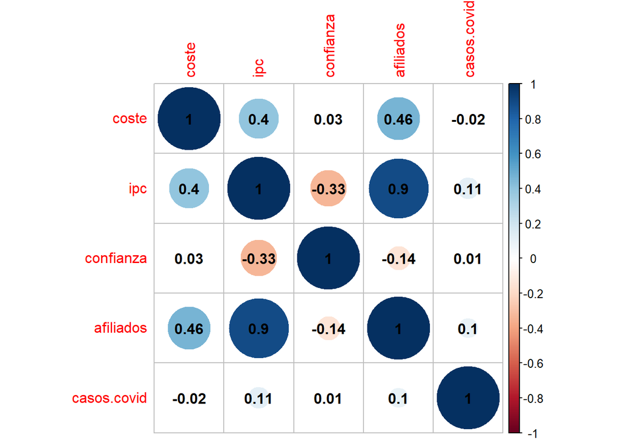

```r
# correlación entre las variables socio-económicas
par(mfrow=c(1,1))
cor(conjunto[,c("coste","ipc","confianza","afiliados","casos.covid")]) |>
  corrplot(addCoef.col="black")
```

En el caso de la serie de GRP parecen existir relaciones. El caso de los minutos de consumo está menos claro. La relación directa entre la inflación y el número de afiliados a la seguridad social parece seguir la teoría que relaciona estas dos variables, según la cual hay menos inflación cuando sube el desempleo, aunque hay estudios que comunican excepciones a esta regla general ( [Campoverde et al., 2016](https://revistas.unl.edu.ec/index.php/economica/article/view/200)).

## 3.2 Aproximación estadística

En los modelos de regresión lineal entrará sólo la primera ola de los contagios de COVID-19 que, como hemos visto en un análisis anterior, tiene la mayor importancia en el ajuste de los modelos.

```r
grp.reg <- lm(GRP~dia+GRP.yearly+covid.1+ipc+afiliados+confianza+coste, data=conjunto)
summary(grp.reg)
```

```
##
## Call:
## lm(formula = GRP ~ dia + GRP.yearly + covid.1 + ipc + afiliados +
##     confianza + coste, data = conjunto)
##
## Residuals:
##      Min       1Q   Median       3Q      Max
## -3095.41  -412.77    79.11   464.41  2973.45
##
## Coefficients:
##               Estimate Std. Error t value Pr(>|t|)
## (Intercept)  1.619e+04  9.374e+02  17.276  < 2e-16 ***
## dia         -5.556e-01  6.681e-02  -8.317  < 2e-16 ***
## GRP.yearly   9.347e-01  2.390e-02  39.118  < 2e-16 ***
## covid.1     -1.893e-01  2.257e-02  -8.386  < 2e-16 ***
## ipc         -1.458e+00  1.019e+01  -0.143  0.88631
## afiliados    9.155e-05  8.553e-05   1.070  0.28461
## confianza    3.407e+01  2.048e+00  16.641  < 2e-16 ***
## coste       -5.105e-01  1.710e-01  -2.986  0.00287 **
## ---
## Signif. codes:  0 '***' 0.001 '**' 0.01 '*' 0.05 '.' 0.1 ' ' 1
##
## Residual standard error: 747.8 on 1818 degrees of freedom
## Multiple R-squared:  0.6221, Adjusted R-squared:  0.6207
## F-statistic: 427.6 on 7 and 1818 DF,  p-value: < 2.2e-16
```

El modelo de regresión de los GRP sugiere que el IPC y el empleo en España no tienen un efecto significativo en la actividad publicitaria en televisión. El coeficiente del ICC es positivo, lo que sugiere más actividad publicitaria en un contexto económico más positivo. El coste tiene un coeficiente negativo, a indicar que a mayor coste corresponde menos actividad publicitaria: **la significación de esta variable en lugar del IPC confirma la suposición según la cual en el mercado de los anuncios televisados la inflación sigue un patrón que no necesariamente se puede describir con el IPC**.

```r
audi.reg <- lm(minutos~dia+audi.yearly+covid.1+ipc+afiliados+confianza+coste, data=conjunto)
summary(audi.reg)
```

```
##
## Call:
## lm(formula = minutos ~ dia + audi.yearly + covid.1 + ipc + afiliados +
##     confianza + coste, data = conjunto)
##
## Residuals:
##     Min      1Q  Median      3Q     Max
## -43.720  -8.004  -1.973   5.809  76.649
##
## Coefficients:
##               Estimate Std. Error t value Pr(>|t|)
## (Intercept)  8.808e+02  1.594e+01  55.246  < 2e-16 ***
## dia         -1.420e-02  1.126e-03 -12.607  < 2e-16 ***
## audi.yearly  9.458e-01  1.836e-02  51.530  < 2e-16 ***
## covid.1      1.070e-02  3.778e-04  28.310  < 2e-16 ***
## ipc         -1.438e+00  1.710e-01  -8.413  < 2e-16 ***
## afiliados   -1.473e-05  1.468e-06 -10.034  < 2e-16 ***
## confianza   -4.611e-01  3.454e-02 -13.351  < 2e-16 ***
## coste        2.221e-02  3.002e-03   7.400 2.07e-13 ***
## ---
## Signif. codes:  0 '***' 0.001 '**' 0.01 '*' 0.05 '.' 0.1 ' ' 1
##
## Residual standard error: 12.57 on 1818 degrees of freedom
## Multiple R-squared:  0.8481, Adjusted R-squared:  0.8475
## F-statistic:  1450 on 7 and 1818 DF,  p-value: < 2.2e-16
```

En el modelo de regresión de la audiencia obtenemos un ajuste muy alto, y todas las variables parecen tener un efecto muy significativo. Sin embargo, la inclusión del coste por GRP en este modelo no parece correcta: **en realidad, quizá el razonamiento correcto sea que el coste del GRP baja cuando hay menos audiencia, y no que la audiencia baje porque el coste del GRP es bajo**. La significación del coeficiente quizá proceda más bien simplemente de la correlación entre las dos variables.

```r
audi.reg.sin.coste <- lm(minutos~dia+audi.yearly+covid.1+ipc+afiliados+confianza, data=conjunto)
summary(audi.reg.sin.coste)
```

```
##
## Call:
## lm(formula = minutos ~ dia + audi.yearly + covid.1 + ipc + afiliados +
##     confianza, data = conjunto)
##
## Residuals:
##     Min      1Q  Median      3Q     Max
## -45.186  -8.076  -1.992   5.965  76.215
##
## Coefficients:
##               Estimate Std. Error t value Pr(>|t|)
## (Intercept)  8.498e+02  1.561e+01  54.444  < 2e-16 ***
## dia         -1.485e-02  1.139e-03 -13.041  < 2e-16 ***
## audi.yearly  1.007e+00  1.666e-02  60.414  < 2e-16 ***
## covid.1      1.079e-02  3.831e-04  28.165  < 2e-16 ***
## ipc         -1.442e+00  1.735e-01  -8.314  < 2e-16 ***
## afiliados   -1.165e-05  1.428e-06  -8.156 6.39e-16 ***
## confianza   -4.541e-01  3.503e-02 -12.962  < 2e-16 ***
## ---
## Signif. codes:  0 '***' 0.001 '**' 0.01 '*' 0.05 '.' 0.1 ' ' 1
##
## Residual standard error: 12.75 on 1819 degrees of freedom
## Multiple R-squared:  0.8435, Adjusted R-squared:  0.843
## F-statistic:  1634 on 6 and 1819 DF,  p-value: < 2.2e-16
```

En el modelo de audiencia sin coste del GRP, volvemos a tener un ajuste muy alto, y las variables IPC, ICC y afiliados a la seguridad social tienen un significativo efecto negativo. En el caso del IPC y del número de afiliados, esto probablemente procede de las tendencias divergentes: en el largo plazo, IPC y número de afiliados suben, mientras la audiencia baja. El coeficiente negativo del ICC quizá dependa de la variabilidad entre el 2020 y el 2021, cuando la variable bajó considerablemente mientras la audiencia subía: **quizá eso fue una dinámica transitoria, seguramente relacionada con la pandemia, que no se debería asumir como regla general** para interpretar la relación entre ICC y audiencia.

# 4 Conclusiones

Las variables socioeconómicas tienen un efecto importante en las métricas de la televisión estudiadas. Sin embargo, **sería prudente seguir las reflexiones realizadas en este análisis**, especialmente las referentes al coste de los GRP en el modelo de audiencia y la relación quizá espuria entre audiencia y confianza del consumidor.